# Probability and Statistics

# Lab Assignment 1: Naive Bayes Classifier

## Work breakdown

- *Zasymovych Bohdan*: preprocessing, fit, predict
- *Hombosh Oleh*: dataset visualization
- *Lyzenko Diana*: metrics calculation and their visualization

## Introduction

During the first three weeks, you learned a couple of essential notions and theorems, and one of the most important among them is the **Bayes theorem**.

**Naive Bayes Classifier** is a simple algorithm, which is based on **Bayes theorem** and used for solving classification problems. **Classification problem** is a problem in which an observation has to be classified in one of the $n$ classes based on its similarity with observations in each class.

It is a **probabilistic classifier**, which means it predicts based on the probability of an observation belonging to each class. To compute it, this algorithm uses **Bayes’ formula,** that you probably already came across in **Lesson 3:**
$$\mathsf{P}(\mathrm{class}\mid
\mathrm{observation})=\frac{\mathsf{P}(\mathrm{observation}\mid\mathrm{class})\mathsf{P}(\mathrm{class})}{\mathsf{P}(\mathrm{observation})}$$

Under the strong **independence** assumption, one can calculate $\mathsf{P}(\mathrm{observation} \mid \mathrm{class})$ as
$$\mathsf{P}(\mathrm{observation}) =
\prod_{i=1}^{n} \mathsf{P}(\mathrm{feature}_i), \qquad
\mathsf{P}(\mathrm{observation} \mid \mathrm{class}) = \prod_{i=1}^{n}
\mathsf{P}(\mathrm{feature}_i \mid \mathrm{class}),$$
where $n$ is the total number of features describing a given observation (*For example, if an observation is presented as a sentence, then each word can be a feature*). Thus, $\mathsf{P}(\mathrm{class}|\mathrm{observation})$ now can be calculated as

$$\mathsf{P}(\mathrm{class} \mid
\mathrm{\mathrm{observation}}) = \mathsf{P}(\mathrm{class})\times
\prod_{i=1}^{n}\frac{\mathsf{P}(\mathrm{feature}_i\mid
\mathrm{class})}{\mathsf{P}(\mathrm{feature}_i)}\tag{1}$$

All the terms on the right-hand side can be estimated as corresponding relative frequencies using available data

**See [*this link*](https://www.javatpoint.com/machine-learning-naive-bayes-classifier) for more detailed explanations & examples :) Also you can watch [*this video*](https://youtu.be/O2L2Uv9pdDA?si=-ohkHVDuu3sLLGMq) for more examples!**

## Data description

There are 5 datasets uploaded on the cms (data.zip)

To determine your variant, take your team number from the list of teams on cms and take *mod 5* - this is the number of your data set.

- **0 - authors** This data set consists of citations of three famous writers: Edgar Alan Poe, Mary Wollstonecraft Shelley and HP Lovecraft. The task with this data set is to classify a piece of text with the author who was more likely to write it.
- **1 - discrimination** This data set consists of tweets that have discriminatory (sexism or racism) messages or of tweets that are of neutral mood. The task is to determine whether a given tweet has discriminatory mood or does not.
- **2 - fake news** This data set contains data of American news: a headline and an abstract of the article. Each piece of news is classified as fake or credible. The task is to classify the news from test.csv as credible or fake.
- **3 - sentiment** All the text messages contained in this data set are labeled with three sentiments: positive, neutral or negative. The task is to classify some text message as the one of positive mood, negative or neutral.
- **4 - spam** This last data set contains SMS messages classified as spam or non-spam (ham in the data set). The task is to determine whether a given message is spam or non-spam.

Each data set consists of two files: *train.csv* and *test.csv*. The first one is used to find the probabilities of the corresponding classes and the second one is used to test your classifier afterwards. Note that it is crucial to randomly split your data into training and testing parts to test the classifierʼs possibilities on the unseen data.

```r
# here goes a list of recommended libraries,
# though you may install other ones if they are needed
library(tidytext)
library(readr)
library(dplyr)
```

```r
library(ggplot2)
library(tidyr) # For reshaping data (convert metrics table for easier plotting)
library(caret) # For createDataPartition
```

## Outline of the work

1. **Data pre-processing** (includes removing punctuation marks and stop words, representing each message as a bag-of-words)
2. **Data visualization** (it’s time to plot your data!)
3. **Classifier implementation** (using the training set, calculate all the conditional probabilities in formula (1))
4. **Measurements of effectiveness of your classifier** (use the results from the previous step to predict classes for messages in the testing set and measure the accuracy, precision and recall, F1 score metric etc)
5. **Conclusions**

*!! do not forget to submit both the (compiled) Rmd source file and the .html output !!*

## Data pre-processing

- Read the *.csv* data files.
- Сlear your data from punctuation or other unneeded symbols.
- Clear you data from stop words. You don’t want words as is, and, or etc. to affect your probabilities distributions, so it is a wise decision to get rid of them. Find list of stop words in the cms under the lab task.
- Represent each test message as its bag-of-words. Here: https://machinelearningmastery.com/gentle-introduction-bag-words-model/ you can find general introduction to the bag-of-words model and examples on to create it.
- It is highly recommended to get familiar with R dataframes, it would make the work much easier to do.
- Useful links:
  - https://steviep42.github.io/webscraping/book/bagofwords.html#tidytext - example of using *tidytext* to count frequencies of the words.
  - Basics of Text Mining in R: http://rstudio-pubs-static.s3.amazonaws.com/256588_57b585da6c054349825cba46685d8464.html . Note that it also includes an example on how to create a bag of words from your text document.

```r
list.files(getwd())
```

```
## [1] "data"
## [2] "Lab1_Naive_Bayes_Classifier_Templatee-4.html"
## [3] "Lab1_Naive_Bayes_Classifier_Templatee-4.Rmd"
## [4] "stop_words.txt"
```

```r
list.files("data/3-sentiment")
```

```
## [1] "test.csv"  "train.csv"
```

```r
test_path <- "data/3-sentiment/test.csv"
train_path <- "data/3-sentiment/train.csv"

stop_words <- read_file("stop_words.txt")
# https://stackoverflow.com/questions/27195912/why-does-strsplit-return-a-list
splitted_stop_words <- strsplit(stop_words, split='\n')
splitted_stop_words <- splitted_stop_words[[1]]
```

```r
train <-  read.csv(file = train_path, stringsAsFactors = FALSE)
test <-  read.csv(file = test_path, stringsAsFactors = FALSE)
```

```r
# note the power functional features of R bring us!
tidy_text <- unnest_tokens(train, 'splitted', 'text', token="words") %>%
             filter(!splitted %in% splitted_stop_words)

tidy_text_test <- unnest_tokens(test, 'splitted', 'text', token="words") %>%
             filter(!splitted %in% splitted_stop_words)
```

## Data visualization

Each time you work with some data, you need to understand it before you start processing it. R has very powerful tools to make nice plots and visualization. Show what are the most common words for negative and positive examples as a histogram, word cloud etc. Be creative!

### Histograms of the most frequent words for each class

For each class (negative, positive, neutral), the 10 most frequent words from the cleaned corpus (after removing stop words) are selected. The data is filtered by class, sorted by frequency, and a horizontal histogram (barplot) is constructed, where the X axis is the word, and the Y axis is the number of its occurrences in the class. This allows you to quickly see which words are most characteristic of each type of message.

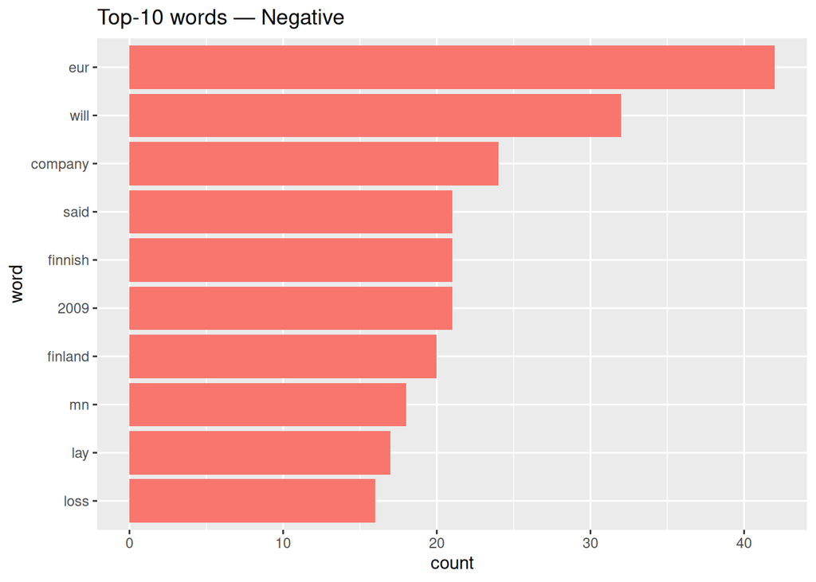

```r
top_neg <- tidy_text %>%
  dplyr::filter(sentiment == "negative") %>%
  dplyr::count(splitted, sort = TRUE) %>%
  dplyr::slice_max(n, n = 10, with_ties = FALSE) %>%
  dplyr::arrange(n) %>%
  dplyr::mutate(splitted = factor(splitted, levels = splitted))

top_pos <- tidy_text %>%
  dplyr::filter(sentiment == "positive") %>%
  dplyr::count(splitted, sort = TRUE) %>%
  dplyr::slice_max(n, n = 10, with_ties = FALSE) %>%
  dplyr::arrange(n) %>%
  dplyr::mutate(splitted = factor(splitted, levels = splitted))

top_neu <- tidy_text %>%
  dplyr::filter(sentiment == "neutral") %>%
  dplyr::count(splitted, sort = TRUE) %>%
  dplyr::slice_max(n, n = 10, with_ties = FALSE) %>%
  dplyr::arrange(n) %>%
  dplyr::mutate(splitted = factor(splitted, levels = splitted))

plot_neg <- ggplot(top_neg, aes(x = splitted, y = n, fill = "negative")) +
  geom_col(show.legend = FALSE) +
  coord_flip() +
  labs(title = "Top-10 words — Negative", x = "word", y = "count")
plot_neg
```

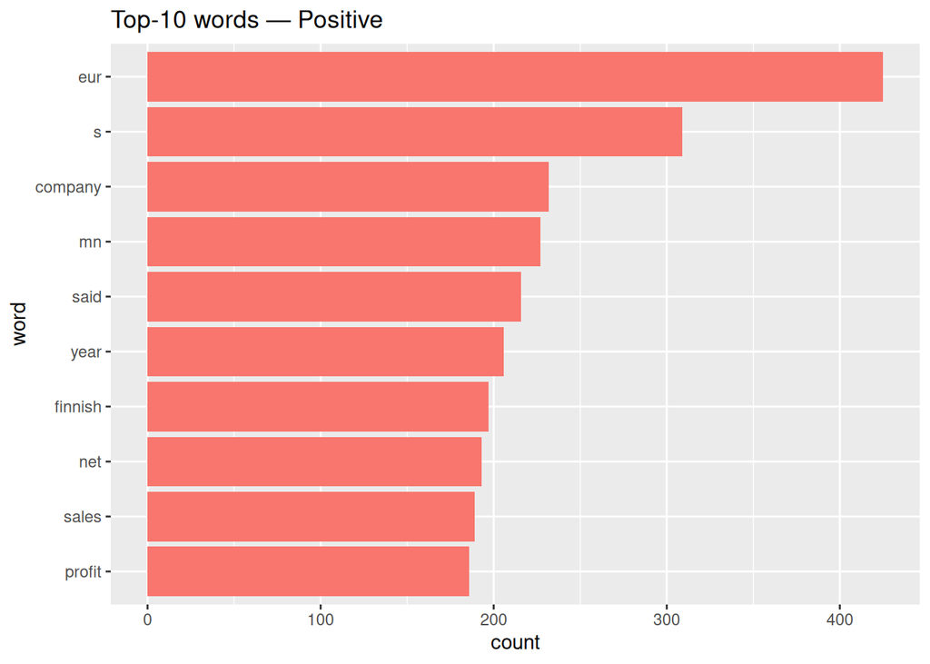

```r
plot_pos <- ggplot(top_pos, aes(x = splitted, y = n, fill = "positive")) +
  geom_col(show.legend = FALSE) +
  coord_flip() +
  labs(title = "Top-10 words — Positive", x = "word", y = "count")
plot_pos
```

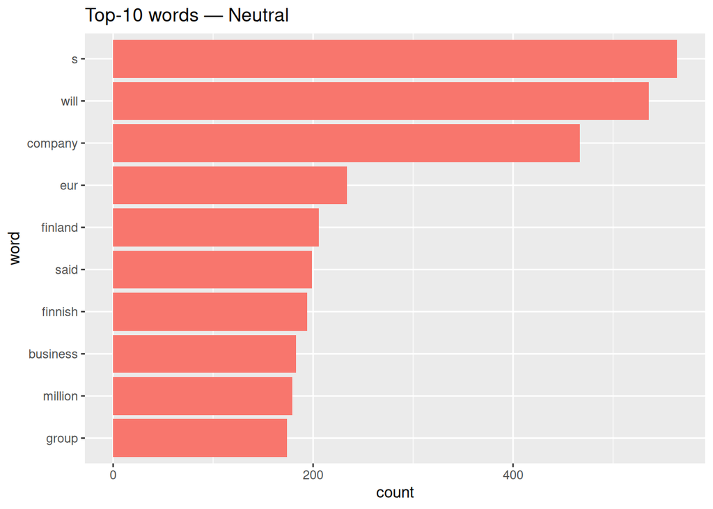

```r
plot_neu <- ggplot(top_neu, aes(x = splitted, y = n, fill = "neutral")) +
  geom_col(show.legend = FALSE) +
  coord_flip() +
  labs(title = "Top-10 words — Neutral", x = "word", y = "count")
plot_neu
```

### Class balance

A simple bar chart is constructed to show whether there is an imbalance between classes. This is important for understanding how class imbalance can affect classification results.

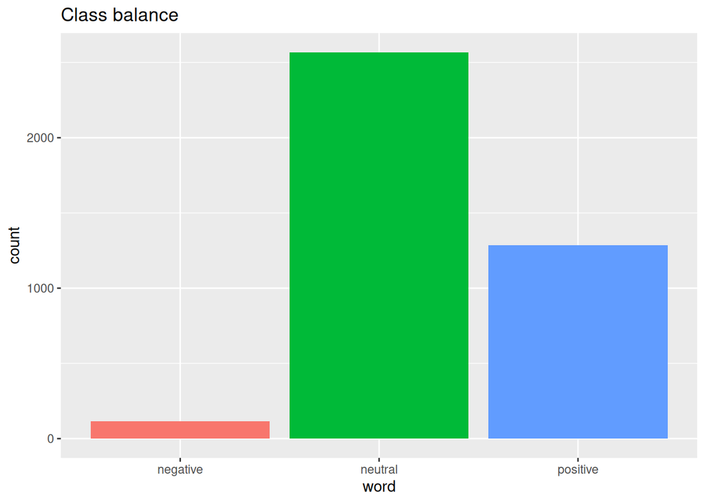

```r
class_balance <- train %>%
  dplyr::count(sentiment)

ggplot(class_balance, aes(x = sentiment, y = n, fill = sentiment)) +
  geom_col(show.legend = FALSE) +
  labs(title = "Class balance", x = "word", y = "count")
```

### n-gram frequencies

Three-grams (sequences of three words) are formed from the text for each class. The 15 most frequent trigrams are selected for each class.

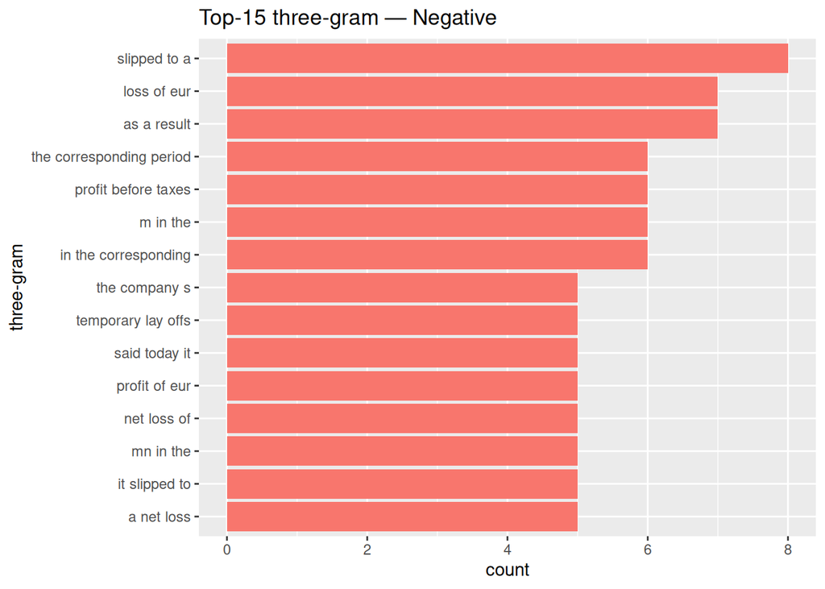

```r
bigrams <- train %>%
  dplyr::select(sentiment, text) %>%
  tidytext::unnest_ngrams(bigram, text, n = 3)

top_bigram <- bigrams %>%
  dplyr::count(sentiment, bigram, sort = TRUE) %>%
  dplyr::group_by(sentiment) %>%
  dplyr::slice_max(n, n = 15, with_ties = FALSE) %>%
  dplyr::ungroup()

neg_bigram <- top_bigram %>%
  dplyr::filter(sentiment == "negative") %>%
  dplyr::arrange(n) %>%
  dplyr::mutate(bigram = factor(bigram, levels = bigram))

plot_neg_bigram <- ggplot(neg_bigram, aes(x = bigram, y = n, fill = sentiment)) +
  geom_col(show.legend = FALSE) +
  coord_flip() +
  labs(title = "Top-15 three-gram — Negative", x = "three-gram", y = "count")
plot_neg_bigram
```

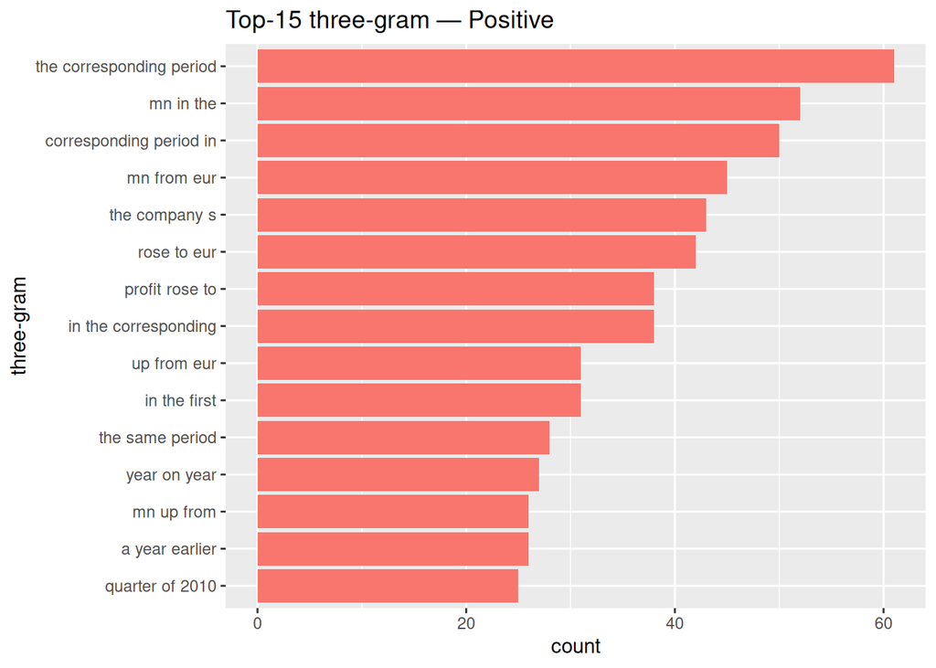

```r
pos_bigram <- top_bigram %>%
  dplyr::filter(sentiment == "positive") %>%
  dplyr::arrange(n) %>%
  dplyr::mutate(bigram = factor(bigram, levels = bigram))

plot_pos_bigram <- ggplot(pos_bigram, aes(x = bigram, y = n, fill = sentiment)) +
  geom_col(show.legend = FALSE) +
  coord_flip() +
  labs(title = "Top-15 three-gram — Positive", x = "three-gram", y = "count")
plot_pos_bigram
```

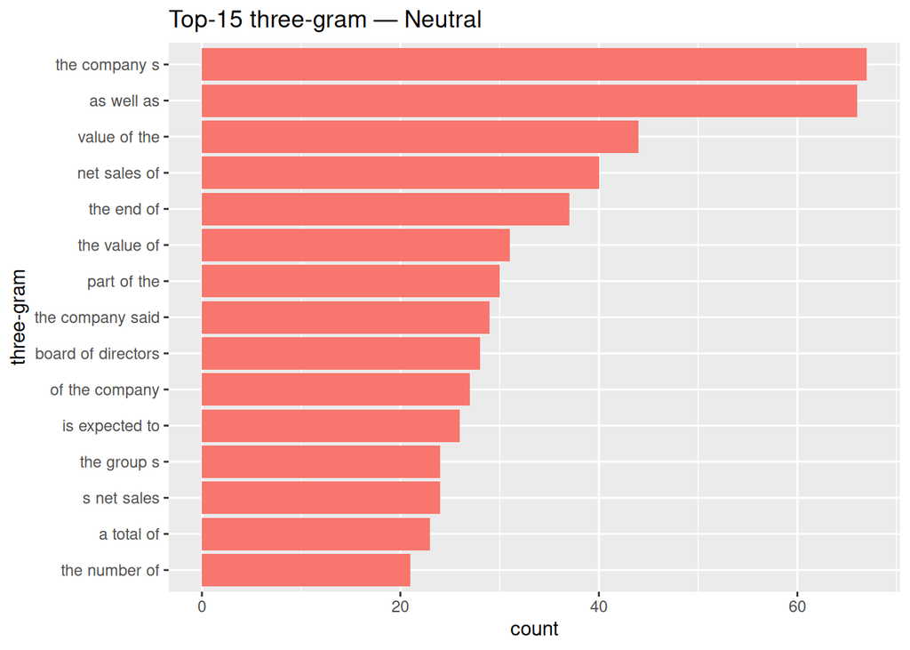

```r
neu_bigram <- top_bigram %>%
  dplyr::filter(sentiment == "neutral") %>%
  dplyr::arrange(n) %>%
  dplyr::mutate(bigram = factor(bigram, levels = bigram))

plot_neu_bigram <- ggplot(neu_bigram, aes(x = bigram, y = n, fill = sentiment)) +
  geom_col(show.legend = FALSE) +
  coord_flip() +
  labs(title = "Top-15 three-gram — Neutral", x = "three-gram", y = "count")
plot_neu_bigram
```

### Common and unique words

For each class, the top 50 most frequent words are selected. The following are determined: words that are in the top 50 for both positive and negative (“shared pos-neg”), words that are only in positive (“unique pos”), only in negative (“unique neg”), only in neutral (“unique neu”). A bar chart is constructed that shows how many words are common and how many are unique for each class.

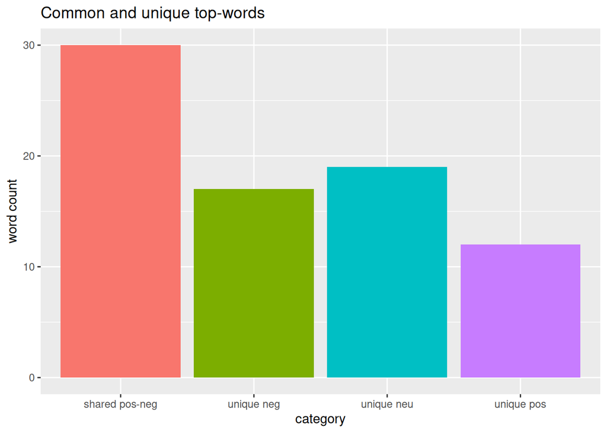

```r
freq_all <- tidy_text %>%
  dplyr::count(sentiment, splitted, sort = TRUE)

top_by_class <- freq_all %>%
  dplyr::group_by(sentiment) %>%
  dplyr::slice_max(n, n = 50, with_ties = FALSE) %>%
  dplyr::ungroup()

pos_words <- top_by_class %>% dplyr::filter(sentiment == "positive") %>% dplyr::pull(splitted)
neg_words <- top_by_class %>% dplyr::filter(sentiment == "negative") %>% dplyr::pull(splitted)
neu_words <- top_by_class %>% dplyr::filter(sentiment == "neutral") %>% dplyr::pull(splitted)

shared_pos_neg <- intersect(pos_words, neg_words)
unique_pos <- setdiff(pos_words, union(neg_words, neu_words))
unique_neg <- setdiff(neg_words, union(pos_words, neu_words))
unique_neu <- setdiff(neu_words, union(pos_words, neg_words))

sets_df <- tibble::tibble(
  set = c("shared pos-neg", "unique pos", "unique neg", "unique neu"),
  size = c(length(shared_pos_neg), length(unique_pos), length(unique_neg), length(unique_neu))
)

ggplot(sets_df, aes(x = set, y = size, fill = set)) +
  geom_col(show.legend = FALSE) +
  labs(title = "Common and unique top-words", x = "category", y = "word count")
```

### Cleansing and its effect

The top 15 most frequent words before cleaning (on raw tokens) and after cleaning (after removing stop words) are compared.

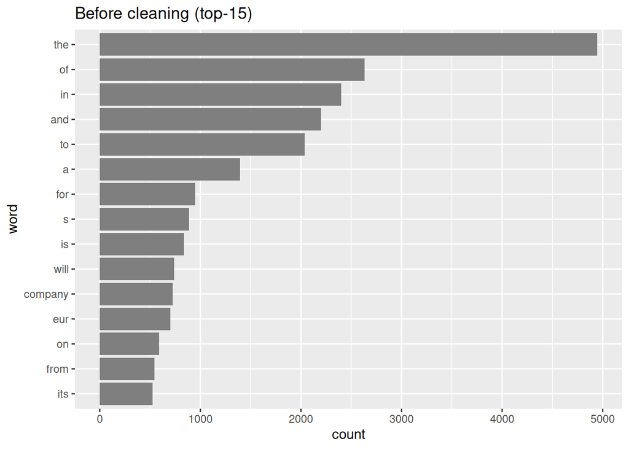

```r
freq_raw <- train %>%
  dplyr::select(sentiment, text) %>%
  tidytext::unnest_tokens(word, text) %>%
  dplyr::count(word, sort = TRUE) %>%
  dplyr::slice_max(n, n = 15, with_ties = FALSE) %>%
  dplyr::mutate(word = factor(word, levels = rev(word)))

freq_clean <- tidy_text %>%
  dplyr::count(splitted, sort = TRUE) %>%
  dplyr::slice_max(n, n = 15, with_ties = FALSE) %>%
  dplyr::mutate(splitted = factor(splitted, levels = rev(splitted)))

p_raw <- ggplot(freq_raw, aes(x = word, y = n)) +
  geom_col(fill = "gray50") +
  coord_flip() +
  labs(title = "Before cleaning (top-15)", x = "word", y = "count")
p_raw
```

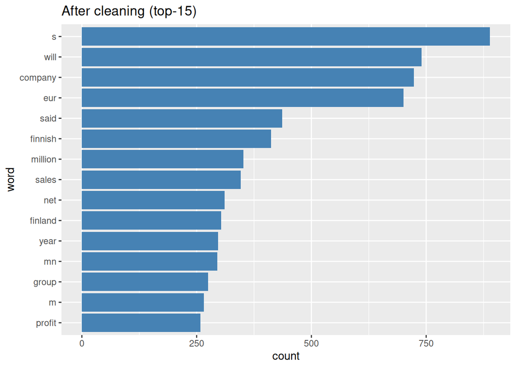

```r
p_clean <- ggplot(freq_clean, aes(x = splitted, y = n)) +
  geom_col(fill = "steelblue") +
  coord_flip() +
  labs(title = "After cleaning (top-15)", x = "word", y = "count")
p_clean
```

## Classifier implementation

```r
naiveBayes <- setRefClass("naiveBayes",

       # here it would be wise to have some vars to store intermediate result
       # frequency dict etc. Though pay attention to bag of words!
       fields = list(
                    # Named vector with probabilities for each class
                    class_probabilities = "numeric",

                    # Matrix where row is a word and column is a class.
                    # Cell represents probability of a word for a class.
                    word_probabilities = "matrix",

                    # Alpha parameter for Laplace smoothing
                    alpha = "numeric"
                    ),

       methods = list(
                    initialize = function(alpha_val=1, ...) { # Initialize default value for alpha
                      alpha <<- alpha_val
                      callSuper(...)
                    },


                    # function pre-processes dataset and returns a matrix.
                    # In matrix each row is a word and column is a class.
                    # Cell represents number of words in this class.
                    preprocess = function(data) {
                      words = unique(data$splitted)
                      classes = c("negative", "neutral", "positive")

                      freq_matr = matrix(0,
                                    nrow=length(words),
                                    ncol=length(classes),
                                    dimnames=list(words, classes)
                                  )

                      for (cls in classes) {
                          class_data <- data[data$sentiment==cls, ]
                          word_counts <- table(class_data$splitted)
                          freq_matr[names(word_counts), cls] <- as.numeric(word_counts)
                      }

                      return(freq_matr)
                    },


                    # Method sets values to class_probabilities and word_probabilities attributes.
                    # X is tidy_text, dataframe where each row is a word and column sentiment is class, column splitted is a word
                    fit = function(X) {
                      freq_matr = preprocess(X) + alpha # Apply Laplace smoothing
                      total_words_per_class <- colSums(freq_matr)
                      word_probabilities <<- sweep(freq_matr, 2, total_words_per_class, FUN="/")

                      class_count <- table(X$sentiment)
                      class_probabilities <<- as.numeric(class_count) / nrow(X)
                      names(class_probabilities) <<- names(class_count)
                    },


                    # Returns prediction for a single message.
                    # For sentiment dataset prediction is "negative", "neutral" or "positive"
                    predict = function(message) {
                      message_df <- data.frame(id=1, text=message, stringsAsFactors=FALSE)
                      message_words <- message_df %>%
                        unnest_tokens(word, text, token="words") %>%
                        filter(!word %in% splitted_stop_words)
                      message_words <- message_words$word[message_words$word %in% rownames(word_probabilities)]

                      if (length(message_words) == 0) {
                        return("neutral")
                      }

                      log_probs <- colSums(log(word_probabilities[message_words, , drop=FALSE]))
                      log_probs <- log_probs + log(class_probabilities)
                      prediction <- names(log_probs)[which.max(log_probs)]

                      return(prediction)
                    },

                    score = function(X_test, y_test) {
                      predictions <- sapply(X_test$text, function(massage) predict(massage))
                      classes <- unique(y_test)
                      metrics <- data.frame()
                      for (cls in classes) {
                        TP <- sum(predictions == cls & y_test == cls)
                        FP <- sum(predictions == cls & y_test != cls)
                        FN <- sum(predictions != cls & y_test == cls)
                        precision <- if (TP + FP > 0) TP / (TP + FP) else 0
                        recall <- if (TP + FN > 0) TP / (TP + FN) else 0
                        f1 <- if (precision + recall > 0) 2 * (precision * recall / (precision + recall)) else 0
                        metrics <- rbind(metrics, data.frame(class=cls, precision=precision, recall=recall, f1=f1)) }
                      return(metrics)
                      }
       )
)
```

## Measure effectiveness of your classifier

- Note that accuracy is not always a good metric for your classifier. Look at precision and recall curves, F1 score metric.

  When evaluating the model, it’s important to understand the different types of classification results:
  - A *true positive* result is one where the model correctly predicts the positive class.
  - A *true negative* result is one where the model correctly predicts the negative class.
  - A *false positive* result is one where the model incorrectly predicts the positive class when it is actually negative.
  - A *false negative* result is one where the model incorrectly predicts the negative class when it is actually positive.

  Precision measures the proportion of true positive predictions among all positive predictions made by the model.

  $$Precision =
  \frac{TP}{TP+FP}$$

  Recall, on the other hand, measures the proportion of true positives identified out of all actual positive cases.

  $$Recall = \frac{TP}{TP+FN}$$

  F1 score is the harmonic mean of both precision and recall.

  $$F1 = \frac{2\times Precision \times
  Recall}{Precision + Recall}$$

  **See [this link](https://cohere.com/blog/classification-eval-metrics) to find more information about metrics.**
- Visualize them.
- Show failure cases.

```r
model <- naiveBayes()
model$fit(tidy_text)
X_test <- test
y_test <- test$sentiment
metrics <- model$score(X_test, y_test)
print(metrics)
```

```
##      class precision      recall         f1
## 1  neutral 0.5714286 0.833333333 0.67796610
## 2 negative 0.5000000 0.006134969 0.01212121
## 3 positive 0.0911271 0.493506494 0.15384615
```

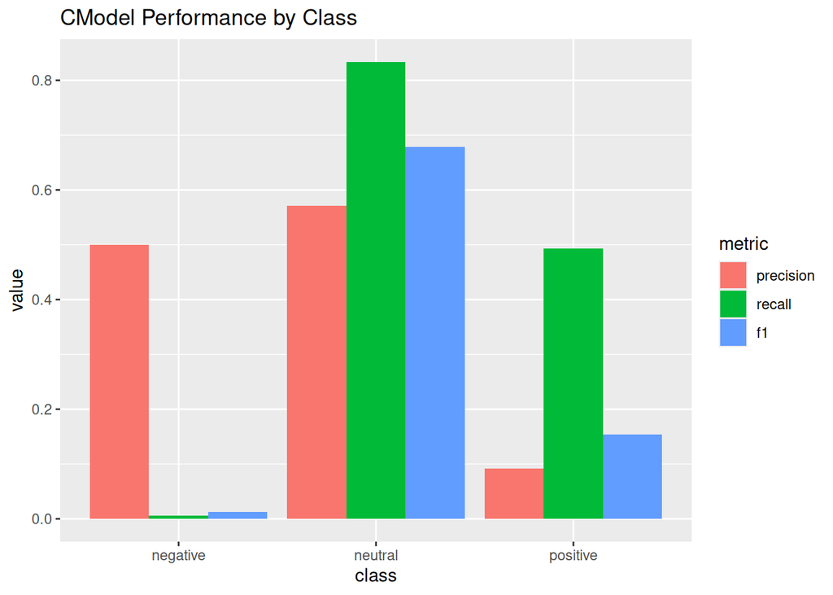

```r
predictions <- sapply(X_test$text, function(msg) model$predict(msg))

metrics_long <- metrics %>% pivot_longer(cols=c(precision, recall, f1),
                                         names_to="metric", values_to="value")
metrics_long$metric <- factor(metrics_long$metric, levels = c("precision", "recall", "f1"))

# Plot precision, recall, and f1 per class
ggplot(metrics_long, aes(x=class, y=value, fill=metric)) +
  geom_bar(stat="identity", position="dodge") +
  labs(title="CModel Performance by Class")
```

```r
# Predictions
predictions <- sapply(X_test$text, function(msg) model$predict(msg))

# Failure cases
failures <- data.frame(
  predicted = predictions[predictions != y_test],
  real      = y_test[predictions != y_test],
  message   = X_test$text[predictions != y_test],
  stringsAsFactors = FALSE
)
# 10 wrong predictions
head(failures, 10)
```

```
##                                                                                                                                                                                                      predicted
## UPM-Kymmene said its has ` not indicated any interest in any domestic consolidations ' .                                                                                                              positive
## Valmet Automotive reports net sales of EUR 85mn and operating profit of EUR 8mn .                                                                                                                     positive
## We bring a new , committed leadership and business and strategic know-how to the company that we buy .                                                                                                positive
## With the government exempting certain stainless steel products from anti-dumping duties , Finland-based Outokumpu today said it will look to enter into supply pacts with the Indian Railways soon .  positive
## The personnel reductions will primarily affect those working for the parent company in the diagnostics business or in production and logistics in the liquid handling business .                       neutral
## In the Asia-Pacific region , Visa Wave is available in Malaysia , Taiwan and South Korea and will be expanded to Japan and Southeast Asia this year , Jung added .                                     neutral
## In the third quarter of fiscal 2008 Efore swung to a net loss of EUR 400,000 versus a net profit of EUR 200,000 for the corresponding period of fiscal 2007 .                                         positive
## Konecranes Oyj KCR1V FH fell 5.5 percent to 20.51 euros , the biggest fall since June .                                                                                                               positive
## Net sales for the financial year 2006 are expected to amount to about EUR20m and the operating result EBIT is expected to be a loss , as announced before .                                           positive
## Operating loss totaled EUR 25mn compared to a profit of EUR 63mn in the corresponding period in 2005 .                                                                                                positive
##                                                                                                                                                                                                          real
## UPM-Kymmene said its has ` not indicated any interest in any domestic consolidations ' .                                                                                                              neutral
## Valmet Automotive reports net sales of EUR 85mn and operating profit of EUR 8mn .                                                                                                                     neutral
## We bring a new , committed leadership and business and strategic know-how to the company that we buy .                                                                                                neutral
## With the government exempting certain stainless steel products from anti-dumping duties , Finland-based Outokumpu today said it will look to enter into supply pacts with the Indian Railways soon .  neutral
## The personnel reductions will primarily affect those working for the parent company in the diagnostics business or in production and logistics in the liquid handling business .                     negative
## In the Asia-Pacific region , Visa Wave is available in Malaysia , Taiwan and South Korea and will be expanded to Japan and Southeast Asia this year , Jung added .                                   positive
## In the third quarter of fiscal 2008 Efore swung to a net loss of EUR 400,000 versus a net profit of EUR 200,000 for the corresponding period of fiscal 2007 .                                        negative
## Konecranes Oyj KCR1V FH fell 5.5 percent to 20.51 euros , the biggest fall since June .                                                                                                              negative
## Net sales for the financial year 2006 are expected to amount to about EUR20m and the operating result EBIT is expected to be a loss , as announced before .                                          negative
## Operating loss totaled EUR 25mn compared to a profit of EUR 63mn in the corresponding period in 2005 .                                                                                               negative
```

[output cut: 11 more lines]

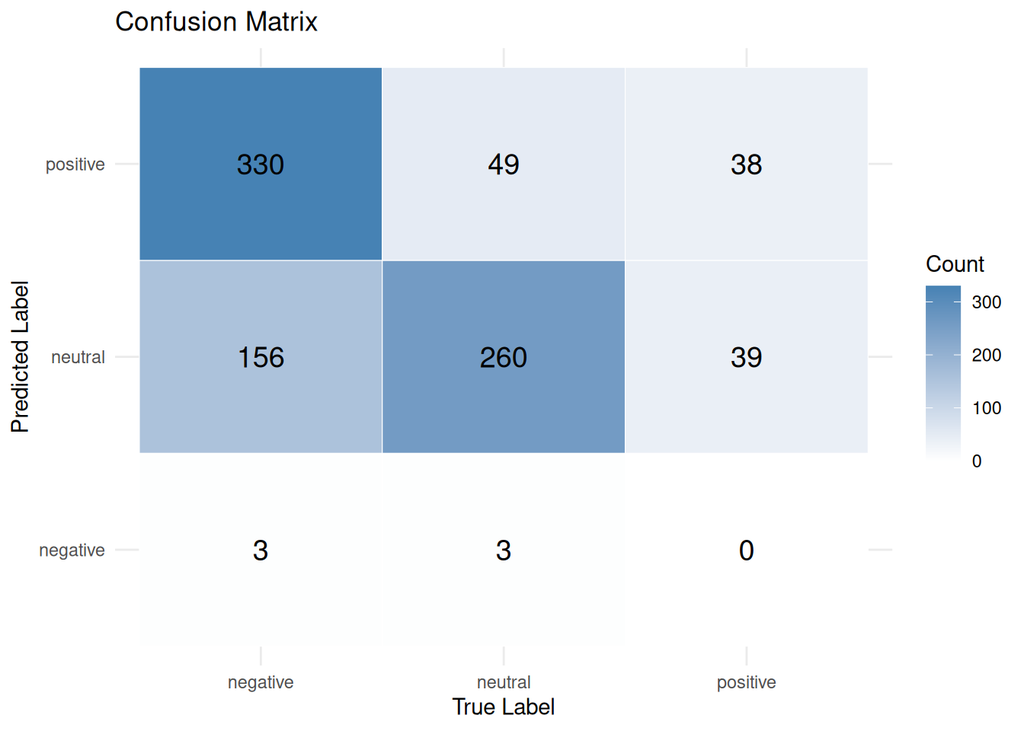

```r
# Confusion matrix
conf_matrix <- table(True = y_test, Predicted = predictions)
conf_df <- as.data.frame(conf_matrix)
colnames(conf_df) <- c("True", "Predicted", "Count")

ggplot(conf_df, aes(x = True, y = Predicted, fill = Count)) +
  geom_tile(color = "white") +
  geom_text(aes(label = Count), color = "black", size = 5) +
  scale_fill_gradient(low = "white", high = "steelblue") +
  labs(title = "Confusion Matrix", x = "True Label", y = "Predicted Label") +
  theme_minimal()
```

```r
# Weighted F1
class_counts <- table(y_test)
metrics$f1_weighted <- metrics$f1 * class_counts[metrics$class]
weighted_f1 <- sum(metrics$f1_weighted) / sum(class_counts)
cat("Weighted F1 score: ", weighted_f1, "\n")
```

```
## Weighted F1 score:  0.2611604
```

## Comparison of train and test sets

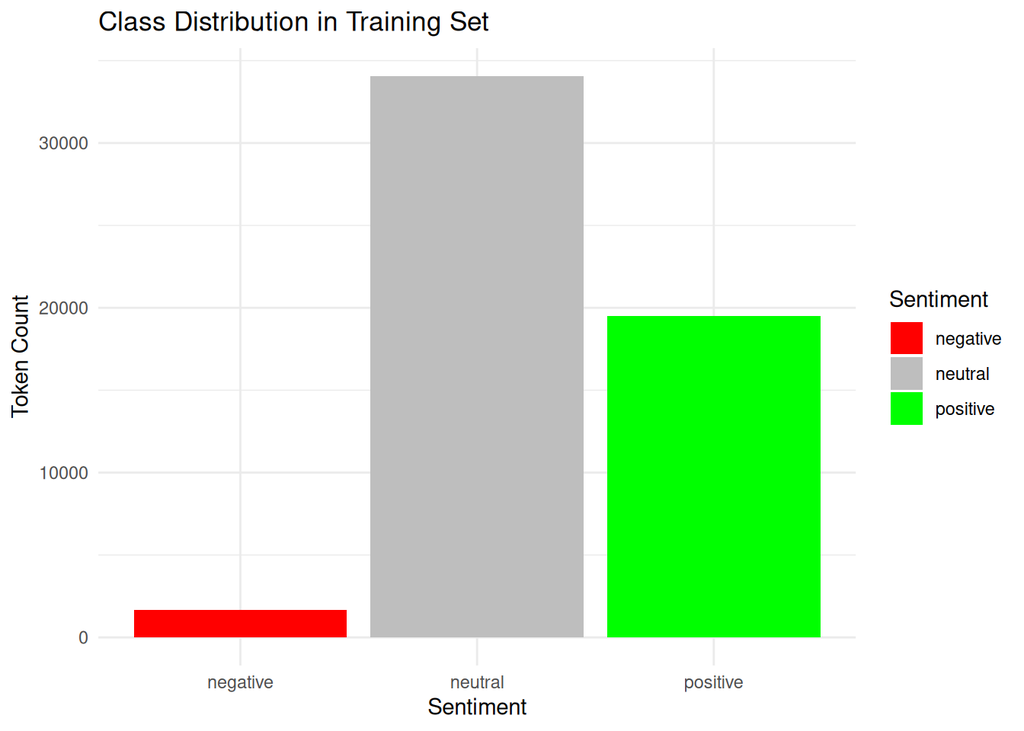

```r
class_counts <- as.data.frame(table(tidy_text$sentiment))
colnames(class_counts) <- c("Sentiment", "Count")

ggplot(class_counts, aes(x = Sentiment, y = Count, fill = Sentiment)) +
  geom_bar(stat = "identity") +
  labs(title = "Class Distribution in Training Set", x = "Sentiment", y = "Token Count") +
  theme_minimal() +
  scale_fill_manual(values = c("negative" = "red", "neutral" = "gray", "positive" = "green"))
```

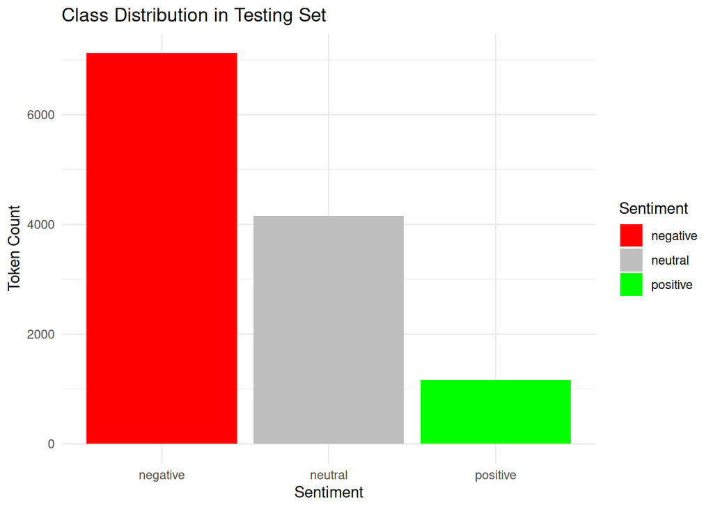

```r
class_counts <- as.data.frame(table(tidy_text_test$sentiment))
colnames(class_counts) <- c("Sentiment", "Count")

ggplot(class_counts, aes(x = Sentiment, y = Count, fill = Sentiment)) +
  geom_bar(stat = "identity") +
  labs(title = "Class Distribution in Testing Set", x = "Sentiment", y = "Token Count") +
  theme_minimal() +
  scale_fill_manual(values = c("negative" = "red", "neutral" = "gray", "positive" = "green"))
```

The train and test splits are highly imbalanced because the class distributions differ significantly between them. As a result, the model performs poorly since it is trained on one distribution but evaluated on another.

To fix this, we combined the two sets and then split them again with preservation of class balance.

```r
# Combine sets
all_data <- bind_rows(train, test)

# Split the data
set.seed(123)
train_index <- createDataPartition(all_data$sentiment, p = 0.8, list = FALSE)
train_balanced <- all_data[train_index, ]
test_balanced  <- all_data[-train_index, ]

# Check the distribution
table(train_balanced$sentiment)
```

```
##
## negative  neutral positive
##      484     2304     1091
```

```r
table(test_balanced$sentiment)
```

```
##
## negative  neutral positive
##      120      575      272
```

```r
# Clear data
tidy_text_balanced <- unnest_tokens(train_balanced, 'splitted', 'text', token="words") %>%
             filter(!splitted %in% splitted_stop_words)

tidy_text_test_balanced <- unnest_tokens(test_balanced, 'splitted', 'text', token="words") %>%
             filter(!splitted %in% splitted_stop_words)
```

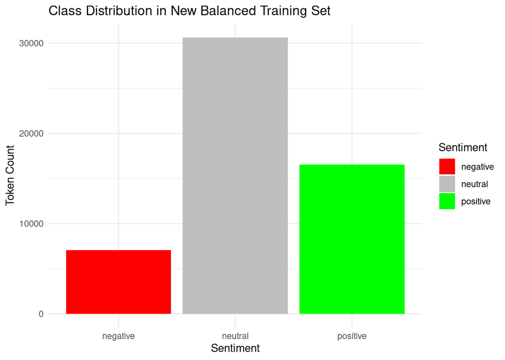

```r
class_counts <- as.data.frame(table(tidy_text_balanced$sentiment))
colnames(class_counts) <- c("Sentiment", "Count")

# bar plot
ggplot(class_counts, aes(x = Sentiment, y = Count, fill = Sentiment)) +
  geom_bar(stat = "identity") +
  labs(title = "Class Distribution in New Balanced Training Set", x = "Sentiment", y = "Token Count") +
  theme_minimal() +
  scale_fill_manual(values = c("negative" = "red", "neutral" = "gray", "positive" = "green"))
```

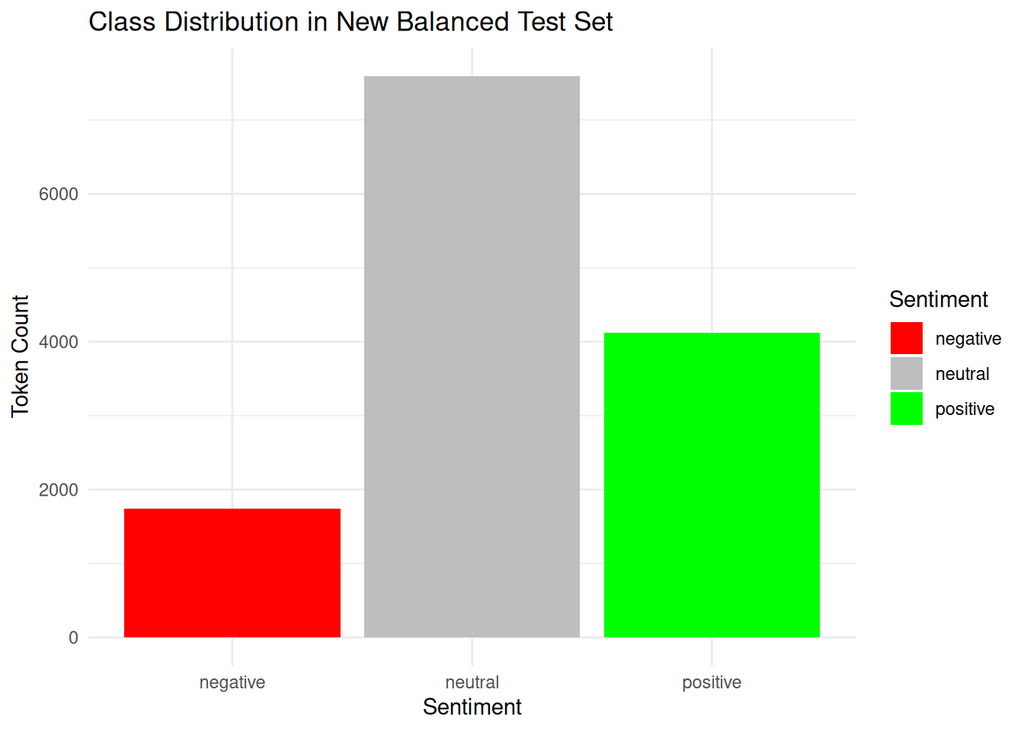

```r
class_counts <- as.data.frame(table(tidy_text_test_balanced$sentiment))
colnames(class_counts) <- c("Sentiment", "Count")

# bar plot
ggplot(class_counts, aes(x = Sentiment, y = Count, fill = Sentiment)) +
  geom_bar(stat = "identity") +
  labs(title = "Class Distribution in New Balanced Test Set", x = "Sentiment", y = "Token Count") +
  theme_minimal() +
  scale_fill_manual(values = c("negative" = "red", "neutral" = "gray", "positive" = "green"))
```

```r
model = naiveBayes()
model$fit(tidy_text_balanced)
X_test <- test_balanced
y_test <- test_balanced$sentiment
metrics <- model$score(X_test, y_test)
print(metrics)
```

```
##      class precision    recall        f1
## 1 positive 0.6040000 0.5551471 0.5785441
## 2  neutral 0.7914013 0.8643478 0.8262677
## 3 negative 0.6179775 0.4583333 0.5263158
```

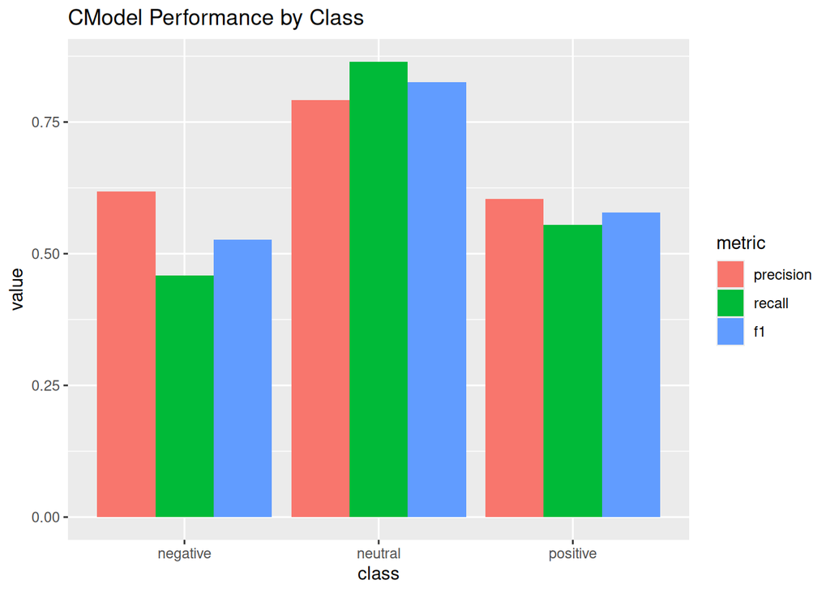

```r
predictions <- sapply(X_test$text, function(msg) model$predict(msg))

metrics_long <- metrics %>% pivot_longer(cols=c(precision, recall, f1), names_to="metric", values_to="value")
metrics_long$metric <- factor(metrics_long$metric, levels = c("precision", "recall", "f1"))

# Plot precision, recall, and f1 for each class
ggplot(metrics_long, aes(x=class, y=value, fill=metric)) +
  geom_bar(stat="identity", position="dodge") +
  labs(title="CModel Performance by Class")
```

```r
# Failure cases
failures <- data.frame(
  predicted = predictions[predictions != y_test],
  real      = y_test[predictions != y_test],
  message   = X_test$text[predictions != y_test],
  stringsAsFactors = FALSE
)
# 10 wrong predictions
head(failures, 10)
```

```
##                                                                                                                                                                                                                                                                                      predicted
## The combination of all services enabling us to offer a complex and strengthened service chain not only limited to the Baltic port connections but also for getting access to the world wide Grimaldi Network into the Mediterranean , Africa and North America `` says Uwe Bakosch .   neutral
## Finnish Bank of +_land 's consolidated net operating profit increased from EUR 4.8 mn in the first quarter of 2005 to EUR 6.4 mn in the first quarter of 2006 .                                                                                                                       negative
## Kalmar Espana generated net sales of some 11.3 mln euro $ 14.8 mln in 2005 .                                                                                                                                                                                                          positive
## `` The purchase of the operations is part of YIT 's strategy to expand its offering of building system services geographically . ''                                                                                                                                                    neutral
## Finnish Aldata Solution has signed a contract of supply its G.O.L.D. system to two French retail chains .                                                                                                                                                                              neutral
## In the fourth quarter of 2009 , Orion 's net profit went up by 33.8 % year-on-year to EUR33m .                                                                                                                                                                                        negative
## Neste Oil Corp. has signed long-term procurement contracts with Honkajoki Oy and Findest Protein Oy , both owned by Finnish food manufacturers , for the supply of animal fat for biodiesel production at Neste 's 200,000 b-cd Porvoo , Finland , refinery .                          neutral
## Profit for the period was EUR 5.9 mn , up from EUR 1.3 mn .                                                                                                                                                                                                                           negative
## The increase in capital stock has been registered in the Finnish Trade Register on 20 November 2006 .                                                                                                                                                                                  neutral
## Via the Satlan acquisition , Teleste plans to further expand its market presence as a video services partner for cable operators , broadcasters and IPTV service providers .                                                                                                           neutral
##                                                                                                                                                                                                                                                                                          real
## The combination of all services enabling us to offer a complex and strengthened service chain not only limited to the Baltic port connections but also for getting access to the world wide Grimaldi Network into the Mediterranean , Africa and North America `` says Uwe Bakosch . positive
## Finnish Bank of +_land 's consolidated net operating profit increased from EUR 4.8 mn in the first quarter of 2005 to EUR 6.4 mn in the first quarter of 2006 .                                                                                                                      positive
```

[output cut: 19 more lines]

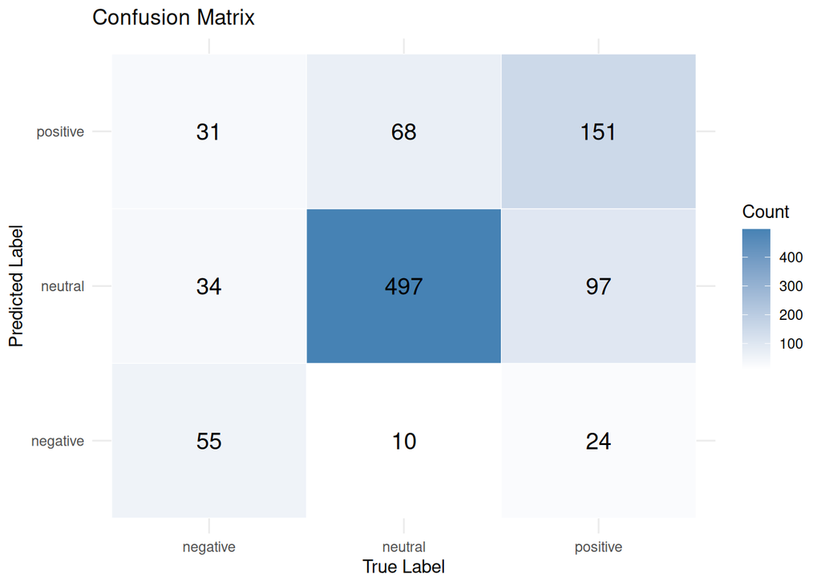

```r
# Build confusion matrix
conf_matrix <- table(True = y_test, Predicted = predictions)
conf_df <- as.data.frame(conf_matrix)
colnames(conf_df) <- c("True", "Predicted", "Count")
ggplot(conf_df, aes(x = True, y = Predicted, fill = Count)) +
  geom_tile(color = "white") +
  geom_text(aes(label = Count), color = "black", size = 5) +
  scale_fill_gradient(low = "white", high = "steelblue") +
  labs(title = "Confusion Matrix", x = "True Label", y = "Predicted Label") +
  theme_minimal()
```

```r
# Calculate weighted F1
class_counts <- table(y_test)
metrics$f1_weighted <- metrics$f1 * class_counts[metrics$class]
weighted_f1 <- sum(metrics$f1_weighted) / sum(class_counts)

cat("Weighted F1 score: ", weighted_f1, "\n")
```

```
## Weighted F1 score:  0.7193648
```

## Conclusions

Summarize your work by explaining in a few sentences the points listed below.

- Describe the method implemented in general. Show what are mathematical foundations you are basing your solution on.
- List pros and cons of the method. This should include the limitations of your method, all the assumption you make about the nature of your data etc.
- Explain why accuracy is not a good choice for the base metrics for classification tasks. Why F1 score is always preferable?

### Data preprocesing

- Loading and cleaning – The raw CSV files are read into R, punctuation or other unnecessary symbols are removed to reduce noise.
- Tokenization – Each message is split into individual words (tokens), transforming text into a structured form suitable for frequency counting.
- Stop-word removal – Common words that do not carry any information for classification are filtered out using a predefined stop-word list.
- Data representation – Each token is represented in a frequency matrix where rows are words and columns are classes. This matrix counts occurrences of each word in each class.

### Classification Method

The classification model is based on **Bayes’ theorem**, which allows computing the probability of a class given an observation. For text classification, the probability of a message belonging to a class is estimated as the product of the probabilities of its words belonging to that class. To handle words that are absent in a class, **Laplace smoothing** is applied during the `fit` step: 1 is added to each word count. This prevents a single unseen word from incorrectly assigning zero probability to a class. During the `predict` step, unknown words are simply ignored, as there is no information about them in the training data. Logarithms are applied to prevent numerical errors that can occur when multiplying many very small probabilities. Since the product of numerous values close to zero can exceed the precision limits of a computer, taking the logarithm of probabilities allows summing them instead, which is more stable and avoids underflow issues. (But for our dataset it appeared unnecessary and didn’t change anything)

**Pros:** - Simple and computationally efficient. - Performs well on high-dimensional data such as text.

**Limitations:** - Does not capture word order in sentences. - Sensitive to class imbalance in the training data. - Assumes conditional independence of words, which is rarely true in practice since the occurrence of one word often affects the probability of the others.

### Metrics and Performnace

To estimate performance of our model we’ve used **precision**, **recall**, **F1 score**. To get better insight into how does model confuses classes **confussion matrix** was created. To evaluate joint performance of a model over all classes **weighted F1 score** was used. Weighed F1 score was used instead of average to account unbalanced distribution of the classes.
$$\text{F1}_{\text{weighted}} = \sum_{i=1}^{C} p_i \cdot \text{F1}_i
\newline \newline p_i - \text{number of elements in a class i over the
total number of elements} \newline F1_i - \text{F1 score for class i}$$

### Why accuracy is insufficient and F1 score is preferable:

Accuracy can be misleading, especially with imbalanced datasets (where one class dominates). For example, in a sentiment analysis task where 90% of messages are neutral and only 10% are positive or negative, a classifier could achieve 90% accuracy by always predicting “neutral,” while completely failing to identify positive or negative messages. The F1 score provides a better measure by balancing precision (how many selected items are relevant) and recall (how many relevant items are selected), making it more robust for evaluating classification performance across all classes.

### Sets imbalance

We have checked the number of messages in each class for both training and test sets and saw that the distributions were very different. Some classes had many more examples than others, which caused the model to misclassify minority classes. To fix this, we created a balanced split that preserved the class proportions in train and test. After doing this, the model’s predictions became more accurate, especially weighted F1 score increased from 0.26 to 0.72.